# Noter - Lektion 5

Johan Ejstrud

2022-04-20

## Tibbles

- Tibbles are Tidyverse’s version of Base R’s Data Frames.

### Printing

- Tibbles are printed in a smarter format than Data Frames. Run and compare below outputs:

```r
library(tidyverse)
as.data.frame(diamonds)
as_tibble(diamonds)
```

- The number of columns and rows used can be controlled with `print()`.

```r
library(nycflights13)

flights %>%
  print(n=100, width = Inf)
```

- To see the entire data set, the best option is to use `view()` which opens the data set in RStudio.

```r
flights %>%
  view()
```

### Data import

- Data imported with Tidyverse functions are always tibbles.
- Data imported with non-Tidyverse functions can be converted to tibbles with `as_tibble()`.

```r
mtcars %>%
  as_tibble()
```

### “Strange” variable names

- Tibbles support variable names with spaces and names that doesn’t start with a letter, by surrounding them back-ticks (``).
- It’s better to change these variable names with the package `janitor`.

```r
df <- read_delim("https://bit.ly/ctd_data_small")

names(df)
 [1] "Cruise"                       "Station"
 [3] "Type"                         "Year"
 [5] "Month"                        "Day"
 [7] "Hour"                         "Minute"
 [9] "Latitude [degrees_north]"     "Longitude [degrees_east]"
[11] "Bot. Depth [m]"               "QV:ODV...12"
[13] "Depth [m]"                    "QV:ODV...14"
[15] "Pressure [dbar]"              "QV:ODV...16"
[17] "Temperature [degC]"           "QV:ODV...18"
[19] "Practical Salinity [dmnless]" "QV:ODV...20"
[21] "Dissolved Oxygen [ml/l]"      "QV:ODV...22"

df %>%
  select(`Depth [m]`)
# A tibble: 1,770 x 1
   `Depth [m]`
         <dbl>
 1           1
 2           2
 3           3
 4           4
 5           5
 6           6
 7           7
 8           8
 9           9
10          10
# ... with 1,760 more rows

library(janitor)

df2 <-
  df %>%
  clean_names()

names(df2)
 [1] "cruise"                     "station"
 [3] "type"                       "year"
 [5] "month"                      "day"
 [7] "hour"                       "minute"
 [9] "latitude_degrees_north"     "longitude_degrees_east"
[11] "bot_depth_m"                "qv_odv_12"
[13] "depth_m"                    "qv_odv_14"
[15] "pressure_dbar"              "qv_odv_16"
[17] "temperature_deg_c"          "qv_odv_18"
[19] "practical_salinity_dmnless" "qv_odv_20"
[21] "dissolved_oxygen_ml_l"      "qv_odv_22"
```

## Tidy data

- Tidy data is the data format all Tidyverse functions expect.
- Tidy data follows a set of rules for how *observations* are organised in *rows* and *columns*.

### Rules

1. Each variable must have its own column.
2. Each observation must have its own row.
3. Each value must have its own cell.

**Simplified rules**: Put each variable in a column.

### Example table

Below `table1` is the only data set that is tidy.

```r
library(tidyverse)
table1
table2
table3
table4a
table4b
```

### Why can’t I use untidy data?

Because it make it really hard to use the Tidyverse functions. Try plotting `population` using the untidy `table4b`. It’s awkward, and not even possible to make a line plot:

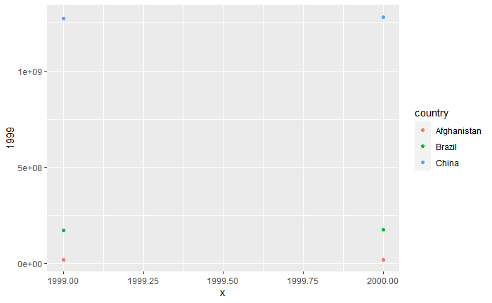

```r
ggplot(table4b, aes(color=country)) +
  geom_point(aes(x=1999, y=`1999`)) +
  geom_point(aes(x=2000, y=`2000`))
```

With the tidy data in `table1`, it’s much easier:

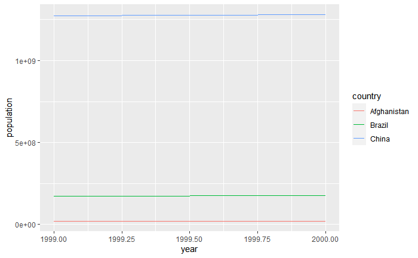

```r
ggplot(table1, aes(x=year, y=population, color=country)) +
  geom_line()
```

### Pivoting

To make tidy data we use:

- `pivot_longer()` if one variable is spread across multiple columns (`table4a`).
- `pivot_wider()` if one observation is scattered across multiple rows (`table2`).

```r
table4a
```

|  | country | 1999 | 2000 |
| --- | --- | --- | --- |
| 1 | Afghanistan | 745 | 2666 |
| 2 | Brazil | 37737 | 80488 |
| 3 | China | 212258 | 213766 |

```r
table4a %>%
  pivot_longer(c(`1999`, `2000`), names_to = "year", values_to = "cases")
```

| country | year | cases |
| --- | --- | --- |
| Afghanistan | 1999 | 745 |
| Afghanistan | 2000 | 2666 |
| Brazil | 1999 | 37737 |
| Brazil | 2000 | 80488 |
| China | 1999 | 212258 |
| China | 2000 | 213766 |

```r
table2
```

| country | year | type | count |
| --- | --- | --- | --- |
| Afghanistan | 1999 | cases | 745 |
| Afghanistan | 1999 | population | 19987071 |
| Afghanistan | 2000 | cases | 2666 |
| Afghanistan | 2000 | population | 20595360 |
| Brazil | 1999 | cases | 37737 |
| Brazil | 1999 | population | 172006362 |
| Brazil | 2000 | cases | 80488 |
| Brazil | 2000 | population | 174504898 |
| China | 1999 | cases | 212258 |
| China | 1999 | population | 1272915272 |

[output cut: 2 more lines]

```r
table2 %>%
  pivot_wider(names_from = type, values_from = count)
```

| country | year | cases | population |
| --- | --- | --- | --- |
| Afghanistan | 1999 | 745 | 19987071 |
| Afghanistan | 2000 | 2666 | 20595360 |
| Brazil | 1999 | 37737 | 172006362 |
| Brazil | 2000 | 80488 | 174504898 |
| China | 1999 | 212258 | 1272915272 |
| China | 2000 | 213766 | 1280428583 |